# FordGoBike

Here, we will analyse and visualise FordGoBike dataset March 2019. This dataset contains infomation about each trip (anonimized). This dataset contains around 256,299 records.

Questions asked on this dataset:

- Which day is the most popular day for bike trip.
- Which type of user take rides more frequently.
- Which age group takes more number of rides.
- Does trip duration depend on age and gender

start_date, member_birth_year, duration_sec and member_gender are the columns focussed on to answer above questions and draw conclusions.

### Univariate Exploration

1. On which day of the week do people take more number of trips.

## Number of Trips taken on each day of the week

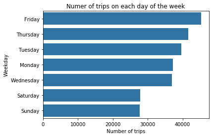

```python
color = sb.color_palette()[0]
order = fgb.weekday.value_counts().index
sb.countplot(data=fgb,y='weekday',order=order,color=color);
plt.title('Numer of trips on each day of the week');
plt.xlabel('Number of trips');
plt.ylabel('Weekday');
```

**Insights**

From the plot, it is evident that most number of trips are recorded on Friday(45233).

As expected, lowest number of trips are recorded during weekend (Saturday and Sunday) as people like to chill out / rest at home.

## Bivariate Exploration

1. In this section, we investigate relationship between user type and their average trip duration.

## User Type and their Average trip duration

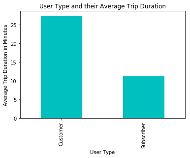

```python
user_dur = fgb.groupby('user_type')['duration_min'].mean()
user_dur.plot(kind='bar',title='User Type and their Average Trip Duration',color='c');
plt.xlabel('User Type');
plt.ylabel('Average Trip Duration in Minutes');
```

**Insights**

From the plot it is evident that people who have not subscribed(Customers) take longer trips compared to that of Subscribers.

The average trip duration is ~27 mins and ~11 minutes for Customers and Subscribers respectively.

1. Here, we will find the average trip duration among different age groups.

## Average trip duration for different Age Groups

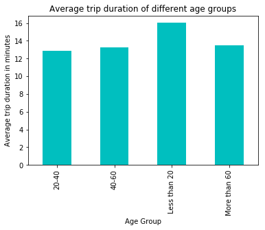

```python
age_dur.plot(kind='bar',title='Average trip duration of different age groups',color='c');
plt.xlabel('Age Group');
plt.ylabel('Average trip duration in minutes');
```

## Trip duration for Different Age groups

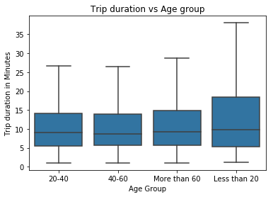

```python
sb.boxplot(data=fgb_year,x='age_group',y='duration_min',showfliers=False,color=sb.color_palette()[0]);
plt.title('Trip duration vs Age group');
plt.xlabel('Age Group');
plt.ylabel('Trip duration in Minutes');
```

**Insights**

From the plot it is evident that

- People of age less than 20(Kids and Teens) take longer trips.
- People of age between 20-40(Youth) take shorter trips compared to all other age groups.
- Mean trip duration of Kids and Teens is 16 minutes.
- The range of trip duration is also high for Kids and Teens.
- Average trip duration for different age groups are as follows:
  - Less than 20 : 16 minutes
  - 20 - 40 : 12.85 minutes
  - 40 - 60 : 13.28 minutes
  - More than 60 : 13.44 minutes

## Trip Duration for different genders born between 1950 to 2000

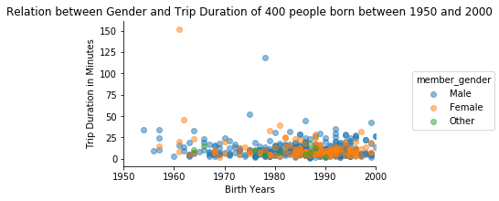

```python
g=sb.FacetGrid(data=fgb_sample,hue='member_gender',aspect=1.6);
g.map(sb.regplot,'member_birth_year','duration_min',fit_reg=False,scatter_kws={'alpha':1/2});
plt.xlim(1950,2000);
g.add_legend();
plt.title('Relation between Gender and Trip Duration of 400 people born between 1950 and 2000');
plt.xlabel('Birth Years');
plt.ylabel('Trip Duration in Minutes');
```